# Rapport d’Analyse des données Titanic

2024-11-14

Informations sur le statut de survie, le sexe, l’âge et la classe des passagers de 1309 passagers dans le naufrage du Titanic en 1912

### Présentation des variables

## Variable ‘sex’

```r
library(carData)
data("TitanicSurvival")

# variable 'sex'
cat("Sexe:\n")
```

```
## Sexe:
```

```r
sex_table <- table(TitanicSurvival$sex)
sex_percentage <- prop.table(sex_table) * 100
cat("Effectifs et pourcentages de chaque sexe :\n")
```

```
## Effectifs et pourcentages de chaque sexe :
```

```r
cat("Hommes (Effectif:", sex_table["male"], ")\n", round(sex_percentage["male"], 2), "%\n")
```

```
## Hommes (Effectif: 843 )
##  64.4 %
```

```r
cat("Femmes (Effectif:", sex_table["female"], ")\n", round(sex_percentage["female"], 2), "%\n\n")
```

```
## Femmes (Effectif: 466 )
##  35.6 %
```

## Variable ‘passengerClass’

```r
# variable 'passengerClass'
cat("Classe des passagers:\n")
```

```
## Classe des passagers:
```

```r
class_table <- table(TitanicSurvival$passengerClass)
class_percentage <- prop.table(class_table) * 100
cat("Effectifs et pourcentages de chaque classe :\n")
```

```
## Effectifs et pourcentages de chaque classe :
```

```r
cat("1ère classe (Effectif:", class_table["1st"], ")\n", round(class_percentage["1st"], 2), "%\n")
```

```
## 1ère classe (Effectif: 323 )
##  24.68 %
```

```r
cat("2ème classe (Effectif:", class_table["2nd"], ")\n", round(class_percentage["2nd"], 2), "%\n")
```

```
## 2ème classe (Effectif: 277 )
##  21.16 %
```

```r
cat("3ème classe (Effectif:", class_table["3rd"], ")\n", round(class_percentage["3rd"], 2), "%\n\n")
```

```
## 3ème classe (Effectif: 709 )
##  54.16 %
```

## Variable ‘survived’

```r
#variable 'survived'
survived_table <- table(TitanicSurvival$survived)
survived_percentage <- prop.table(survived_table) * 100
cat("Effectifs et pourcentages des survivants :\n")
```

```
## Effectifs et pourcentages des survivants :
```

```r
cat("Survivants (Effectif:", survived_table["yes"], ")\n", round(survived_percentage["yes"], 2), "%\n")
```

```
## Survivants (Effectif: 500 )
##  38.2 %
```

```r
cat("Non-survivants (Effectif:", survived_table["no"], ")\n", round(survived_percentage["no"], 2), "%\n")
```

```
## Non-survivants (Effectif: 809 )
##  61.8 %
```

```r
cat("\n")
```

## Variable ‘age’

```r
#variable 'age'
min_age <- min(TitanicSurvival$age, na.rm = TRUE)
max_age <- max(TitanicSurvival$age, na.rm = TRUE)
etendue <- max_age - min_age
q1 <- quantile(TitanicSurvival$age, 0.25, na.rm = TRUE)
q2 <- median(TitanicSurvival$age, na.rm = TRUE)  # médiane
q3 <- quantile(TitanicSurvival$age, 0.75, na.rm = TRUE)
iqr <- q3 - q1
moy <- mean(TitanicSurvival$age, na.rm = TRUE)
et <- sd(TitanicSurvival$age, na.rm = TRUE)
na_count <- sum(is.na(TitanicSurvival$age))
effectif_age <- sum(!is.na(TitanicSurvival$age))

cat("Statistiques descriptives pour l'âge :\n")
```

```
## Statistiques descriptives pour l'âge :
```

```r
cat("Effectif (sans valeurs manquantes):", effectif_age, "\n")
```

```
## Effectif (sans valeurs manquantes): 1046
```

```r
cat("Minimum:", min_age, "\n")
```

```
## Minimum: 0.1667
```

```r
cat("Maximum:", max_age, "\n")
```

```
## Maximum: 80
```

```r
cat("Étendue:", etendue, "\n")
```

```
## Étendue: 79.8333
```

```r
cat("Premier quartile (Q1):", q1, "\n")
```

```
## Premier quartile (Q1): 21
```

```r
cat("Médiane (Q2):", q2, "\n")
```

```
## Médiane (Q2): 28
```

```r
cat("Troisième quartile (Q3):", q3, "\n")
```

```
## Troisième quartile (Q3): 39
```

```r
cat("Écart interquartile (IQR):", iqr, "\n")
```

```
## Écart interquartile (IQR): 18
```

```r
cat("Moyenne:", round(moy, 2), "\n")
```

```
## Moyenne: 29.88
```

```r
cat("Écart-type:", round(et, 2), "\n")
```

```
## Écart-type: 14.41
```

```r
cat("Nombre de valeurs manquantes:", na_count, "\n")
```

```
## Nombre de valeurs manquantes: 263
```

## Graphique : Répartition des survivants en fonction du sexe et de la classe des passagers

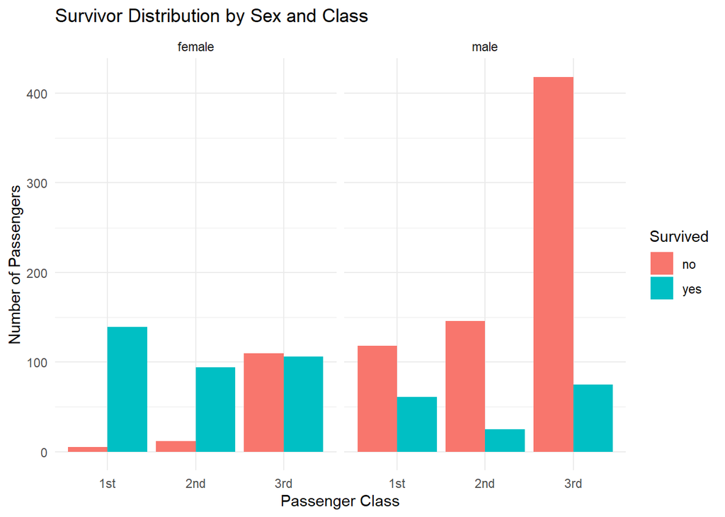

```r
library(carData)
library(ggplot2)
data("TitanicSurvival")

TitanicSurvival$survived <- as.factor(TitanicSurvival$survived)
TitanicSurvival$sex <- as.factor(TitanicSurvival$sex)
TitanicSurvival$passengerClass <- as.factor(TitanicSurvival$passengerClass)

# Visualiser la répartition des survivants par sexe et classe
ggplot(TitanicSurvival, aes(x = passengerClass, fill = survived)) +
  geom_bar(position = "dodge", na.rm = TRUE) +  # Position dodge pour éviter le chevauchement
  facet_wrap(~ sex) +  # Séparer les graphiques par sexe
  labs(title = "Survivor Distribution by Sex and Class",
       x = "Passenger Class",
       y = "Number of Passengers",
       fill = "Survived") +
  theme_minimal()
```

## Graphique de la survie en fonction de l’âge

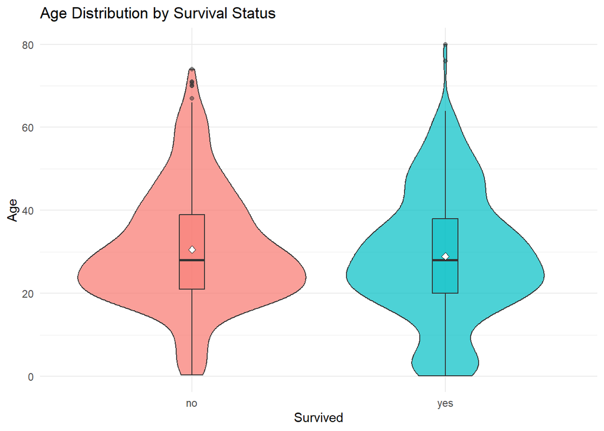

```r
library(carData)
library(ggplot2)
data("TitanicSurvival")
ggplot(subset(TitanicSurvival, !is.na(age)),
       aes(x = survived, y = age, fill = survived)) +
  geom_violin(alpha = 0.7) +
  geom_boxplot(width = 0.1, alpha = 0.5) +
  labs(title = "Age Distribution by Survival Status",
       x = "Survived",
       y = "Age",
       fill = "Survived") +
  theme_minimal() +
  stat_summary(fun = "mean",
              geom = "point",
              shape = 23,
              size = 2,
              color = "black",
              fill = "white") +
    theme(legend.position = "none")
```

Le graphique montre que l’âge était également un facteur influençant les chances de survie sur le Titanic. Les très jeunes enfants (moins de 10 ans) ont eu de meilleures chances de survie que les adultes. La moyenne d’âge des survivants est légèrement inférieure à celle des non-survivants. Cela suggère que les procédures d’évacuation ont donné la priorité aux passagers les plus jeunes. Cependant, on observe aussi que les personnes âgées ont eu des taux de survie plus faibles, probablement en raison de difficultés à accéder rapidement aux canots de sauvetage.

## Interprétation des résultats

## 1. Relation entre Survie et Sexe :

- Une forte disparité entre hommes et femmes est visible.
- Les femmes ont eu un taux de survie nettement supérieur.

Cette différence majeure s’explique par la règle “les femmes et les enfants d’abord” lors de l’évacuation.

## 2. Relation entre Survie et Classe :

On observe une hiérarchie claire dans les taux de survie :

- 1ère classe : le meilleur taux de survie.
- 2ème classe : taux de survie intermédiaire.
- 3ème classe : taux de survie le plus faible.

Ces différences peuvent s’expliquer par :

- L’emplacement des cabines (plus proche des canots pour la 1ère classe).
- L’accès à l’information pendant le naufrage.
- Le traitement prioritaire des passagers de première classe.

## 3. Relation entre Survie et Âge :

- Les enfants (moins de 10 ans) ont eu de meilleures chances de survie.
- La distribution des âges est différente entre survivants et non-survivants.
- Les personnes très âgées semblent avoir eu moins de chances de survie.
- La moyenne d’âge des survivants est légèrement plus basse que celle des non-survivants.

## 4. Interactions entre variables :

Les meilleures chances de survie étaient pour :

- Les femmes de première classe (taux le plus élevé).
- Les femmes de deuxième classe.
- Les femmes de troisième classe.

## Conclusion générale :

- Le sexe était le facteur le plus déterminant pour la survie.
- La classe sociale jouait un rôle important mais secondaire.
- L’âge avait une influence, particulièrement pour les très jeunes passagers.

Ces résultats reflètent les normes sociales de l’époque et les procédures d’évacuation du Titanic, avec une priorité claire donnée aux femmes et aux enfants, ainsi qu’un avantage significatif pour les passagers des classes supérieures.

## Fonction pour calculer le taux de survie par classe

```r
library(dplyr)
library(TitanicPackage)
library(carData)
data("TitanicSurvival")

taux_survie_classe <- calculate_survival_rate_by_class(TitanicSurvival)
print(taux_survie_classe)
```

```
## # A tibble: 3 × 4
##   passengerClass total survived survival_rate
##   <fct>          <int>    <int>         <dbl>
## 1 1st              323      200          61.9
## 2 2nd              277      119          43.0
## 3 3rd              709      181          25.5
```

## Fonction pour calculer le taux de survie par sexe

```r
library(dplyr)
library(TitanicPackage)
library(carData)
data("TitanicSurvival")

taux_survie_sex <- calculate_survival_rate_by_sex(TitanicSurvival)
print(taux_survie_sex)
```

```
## # A tibble: 2 × 4
##   sex    total survived survival_rate
##   <fct>  <int>    <int>         <dbl>
## 1 female   466      339          72.8
## 2 male     843      161          19.1
```